# Assignment 4

Author

Daniel Fang, Cloris Li

```r
library(tidycensus)
library(tidyverse)
library(tigris)
library(ggplot2)
library(sf)
library(here)
library(tidyr)
```

# Introduction

In this assignment, we explored retrieving the American Community Survey (ACS) data using our API key and made visualizations that describe the demographic information of selected regions. We intend to use these visualizations to start our analysis on the relationship between demographic characteristics and public transportation in the Washington metropolitan area. Creating visualizations on the region is a challenge as it requires binding data from DC, VA and MD. In this portfolio, we begin with an overview of the public transportation scene in U.S. major cities, and then zoom in on analyzing Northern Virginia. Some visualizations are inspired by class exercises and online tutorials about ACS data analysis.

# Graph 1: Public Transit Ridership in Major U.S. Cities in 2021

```r
ridership <-  get_acs(
  geography = "cbsa",
  #public transit commute share
  variables = "DP03_0021P",
  summary_var = "B01003_001",
  survey = "acs1",
  year = 2021
) %>%
  slice_max(summary_est, n = 15)
```

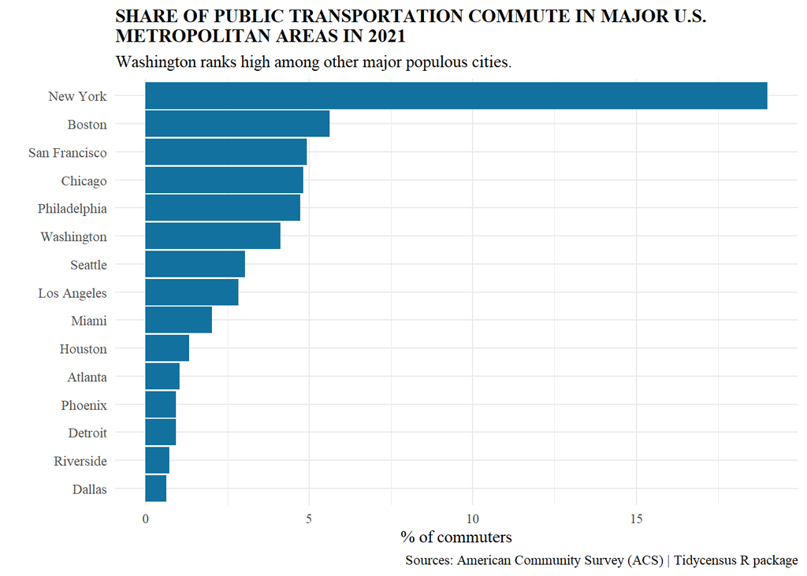

```r
ridership %>%
  mutate(NAME = str_remove(NAME, "-.*$")) %>%
  mutate(NAME = str_remove(NAME, ",.*$")) %>%
  ggplot(aes(y = reorder(NAME, estimate), x = estimate)) +
  geom_col(color = "#12719e",
    fill = "#12719e") +
  labs(title = "SHARE OF PUBLIC TRANSPORTATION COMMUTE IN MAJOR U.S.\nMETROPOLITAN AREAS IN 2021",
       subtitle = "Washington ranks high among other major populous cities.",
       caption = "Sources: American Community Survey (ACS) | Tidycensus R package",
       y = "",
       x = "% of commuters") +
  theme_minimal() +
  theme(text = element_text(family = "serif"),
        plot.title = element_text(face="bold", size = 11.5))
```

Graph 1 is an overview of the public transportation scene in major U.S. cities. Each bar indicates the share of public transit in a certain metropolitan area’s total commute. In 2021, COVID-19 severely impacted on-site work and public transit usage, but cities that are more transit-oriented traditionally still show robust ridership results.

# Graph 2: Median Household Income Across Arlington, Virginia

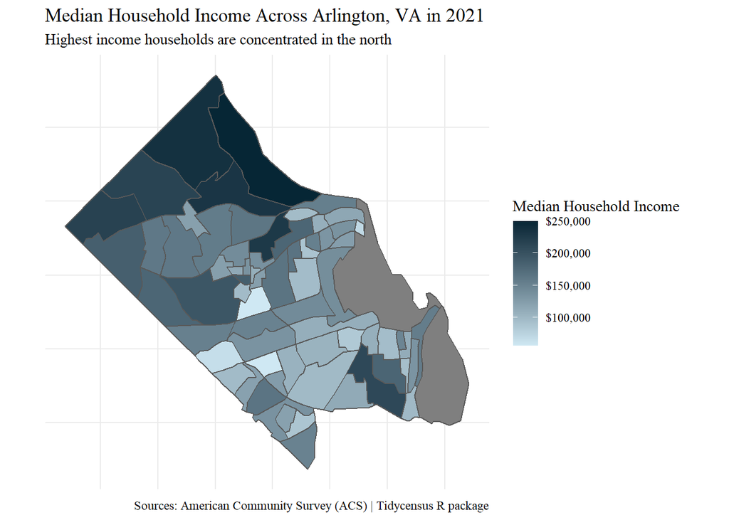

```r
ar_income <- get_acs(
  geography = "tract",
  #median household income
  variables = "B19013_001",
  state = "VA",
  county = "Arlington",
  geometry = TRUE,
  year = 2021,
  progress = FALSE
)

ggplot()+
  geom_sf(data = ar_income, aes(fill = estimate) ) +
  scale_fill_gradient(low = "#cfe8f3" , high = "#062635",
                      labels = scales::dollar,
                      name = "Median Household Income") +
  labs(title = "Median Household Income Across Arlington, VA in 2021",
       subtitle = "Highest income households are concentrated in the north",
       caption = "Sources: American Community Survey (ACS) | Tidycensus R package") +
  theme_minimal() +
  theme(text = element_text(family = "serif"),
        axis.text.x=element_blank(),
        axis.text.y=element_blank())
```

Graph 2 is a choropleth of the median household income estimates for Arlington, VA and shows the spatial distribution of median household incomes across the region. Each census tract is shaded based on its median household income, with darker shades representing higher incomes and lighter shades lower incomes.

# Graph 3: Median Home Value in Northern Virginia

```r
values <- get_acs(
  geography = "tract",
# median home value
  variables = "B25077_001",
  state = "VA",
  year = 2021,
  county = c(
    "Arlington",
    "Alexandria",
    "Fairfax County",
    "Falls Church",
    "Loudoun"
  )
)%>%
# separate NAME column into columns for tract, county, and state
  separate(
  NAME,
  into = c("tract", "county", "state"),
  sep = ", "
)
```

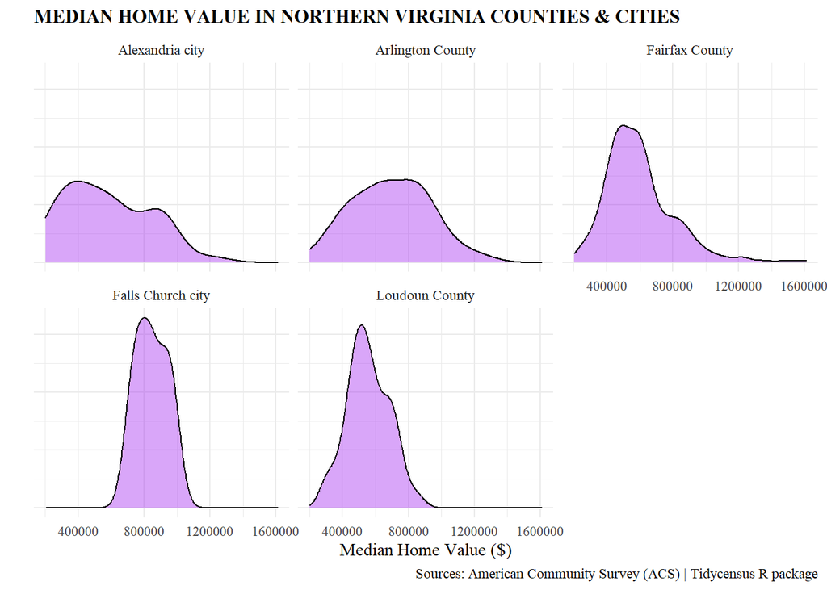

```r
ggplot()+
  geom_density(data = values, aes(x = estimate), alpha = 0.4, fill = "purple") +
  facet_wrap(~county) +
  theme_minimal()+
  labs(title = "MEDIAN HOME VALUE IN NORTHERN VIRGINIA COUNTIES & CITIES",
       caption = "Sources: American Community Survey (ACS) | Tidycensus R package",
       y = "",
       x = "Median Home Value ($)") +
  theme_minimal() +
  theme(text = element_text(family = "serif"),
        plot.title = element_text(face="bold", size = 11.5),
        axis.text.y = element_blank())
```

Graph 3 is a wrapped density plot that exhibits median home value in counties and cities in northern Virginia, with a focus on Alexandria, Arlington, Fairfax, Falls Church, and Loudoun. Among these regions, Falls Church has the smallest spread around a high median of approximately 800,000 dollars.

# Graph 4: Public Transit Ridership in Northern Virginia from 2010 to 2019

```r
years <- 2010:2019
names(years) <- years
variders <- map_dfr(years, ~{
  get_acs(
    geography = "county",
    variables = "DP03_0021P",
    summary_var = "B01003_001",
    survey = "acs1",
    state = "VA",
    county = c(
    "Arlington",
    "Alexandria",
    "Fairfax County",
    "Falls Church",
    "Loudoun"
    ),
    year = .x
  )
}, .id = "year") %>%
# separate NAME column into columns for tract, county, and state
  separate(
  NAME,
  into = c("county", "state"),
  sep = ", "
)
```

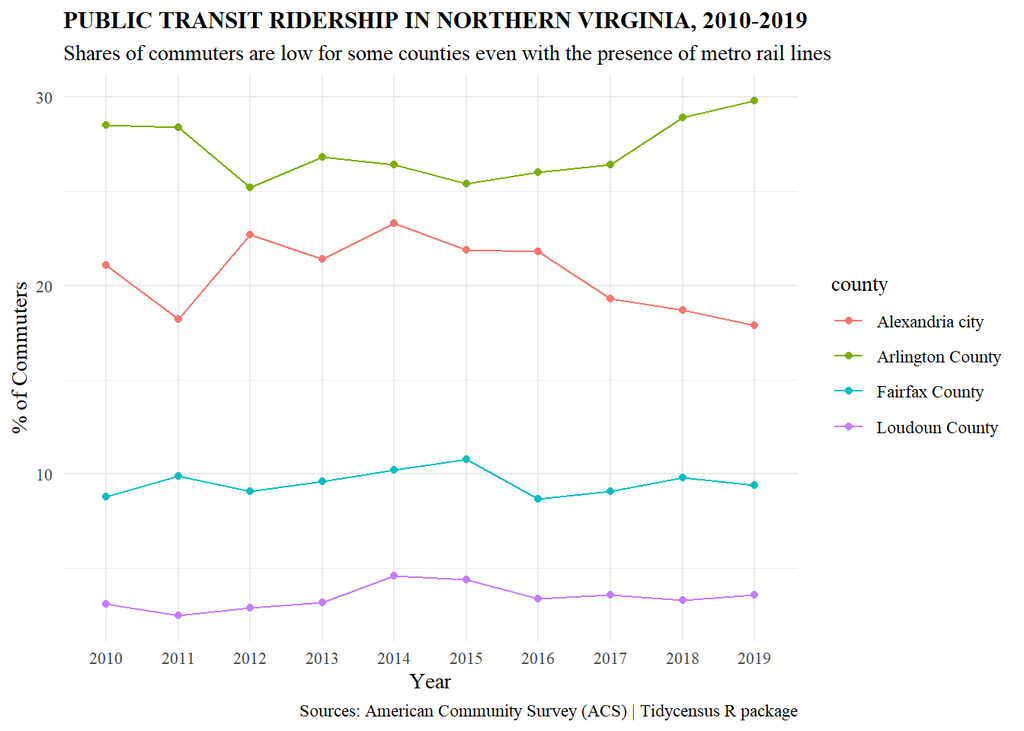

```r
ggplot(variders, aes(x = year, y = estimate, color = county, group = 4)) +
  geom_line(aes(group = county)) +
  geom_point() +
  theme_minimal()+
  labs(title = "PUBLIC TRANSIT RIDERSHIP IN NORTHERN VIRGINIA, 2010-2019",
       subtitle = "Shares of commuters are low for some counties even with the presence of metro rail lines",
       caption = "Sources: American Community Survey (ACS) | Tidycensus R package",
       y = "% of Commuters",
       x = "Year") +
  theme_minimal() +
  theme(text = element_text(family = "serif"),
        plot.title = element_text(face="bold", size = 11.5))
```

Graph 4 is a line chart that captures ridership data similar to graph 1. It shows the changes in public transit ridership in respectively, Alexandria, Arlington, Fairfax, and Loudoun from 2010 to 2019. Among the aforementioned regions in northern Virginia, Arlington consistently has the highest share of public transit commuters.